# DAPC_Ppor_Host

Veronica Radice

21/04/2021

# Coral Host *Porites porites*

# Discriminant Analysis of Principal Components (DAPC)

### A discriminant function analysis

Investigating genetic diversity using multivariate approaches relies on finding synthetic variables built as linear combinations of alleles and which reflect as well as possible the genetic variation amongst the studied individuals.

However, most of the time we are not only interested in the diversity amongst individuals, but also and possibly more so in the diversity between groups of individuals. Typically, one will be analysing individual data to identify populations, or more largely genetic clusters, and then describe these clusters.

A problem occuring in traditional methods is they usually focus on the entire genetic variation. Genetic variability can be decomposed using a standard multivariate ANOVA model as:

```
total variance = (variance between groups) + (variance within groups)
```

or more simply, denoting X the data matrix:

```
VAR(X) = B(X) +W(X)
```

Usual approaches such as Principal Component Analysis (PCA) or Principal Coordinates Analysis (PCoA / MDS) focus on VAR(X). That is, they only describe the global diversity, possibly overlooking differences between groups.

On the contrary, DAPC optimizes B(X) while minimizing W(X): it seeks synthetic variables, the **discriminant functions**, which show differences between groups as best as possible while minimizing variation within clusters.

### Method

This method aims to identify and describe genetic clusters: - use find.clusters to identify clusters - use dapc to describe the relationships between these clusters

### Resources

See DAPC tutorial using the adegenet package (Thibaut Jombart, Caitlin Collins): https://github.com/thibautjombart/adegenet/wiki/Tutorials

Jombart T, Devillard S and Balloux F (2010) Discriminant analysis of principal components: a new method for the analysis of genetically structured populations. BMC Genetics11:94. doi:10.1186/1471-2156-11-94

https://github.com/JoannaGriffiths/Coral-population-responses-to-acidification/blob/master/DAPC%20analysis/DAPC.R

WGCNA_DFA_Final.R - Kenkel & Matz (2016) https://datadryad.org/stash/dataset/doi:10.5061/dryad.2bv13

# Load packages

```r
# For first time installation
#library(devtools)
#install_github("thibautjombart/adegenet")
# or
#install.packages("adegenet")

library(adegenet)
library(SummarizedExperiment)
library(data.table)
library(tidyverse)
library(plyr)
```

# Set working directory

```r
setwd("~/Documents/Rprojects/postdoc\ Rprojects/ODU_postdoc_Rprojects/Paper_Ojo_gene-expression/Porites_porites/host/")
```

## Import metadata

```r
meta <- read.csv("~/Documents/Rprojects/postdoc\ Rprojects/ODU_postdoc_Rprojects/Paper_Ojo_gene-expression/Porites_porites/Porites_porites_Year-2_metadata.csv", header=TRUE, row.names=1)

# Remove all samples that were transplanted to the Destination Ojo.Norte
# There is no control site for Norte Ojo
# For now, we are focused on samples transplanted to Laja Control or Laja Ojo sites
# This is consistent with analyses for the other 2 species in the experiment
# Also, group sample size is too small for Ojo.Norte destination

meta <- subset(meta, Destination_name != "Ojo.Norte")
```

```r
meta$Destination_type <- revalue(meta$Destination_type, c("control" = "Control", "ojo" = "Ojo"))

meta <- meta %>% unite(group, Origin_type, Destination_type, sep = ".", remove = FALSE)


meta[sapply(meta, is.character)] <- lapply(meta[sapply(meta, is.character)],
                                       as.factor)
# Colony_ID is equivalent to genotype
meta$Colony_ID <- as.factor(meta$Colony_ID)

levels(meta$group)
```

```
## [1] "Reef.Control" "Reef.Ojo"
```

# select relevant metadata

```r
meta <- dplyr::select(meta, Colony_ID, group, Origin_name, Origin_type, Destination_name, Destination_type, pH_Destination)
```

### Remove samples with >85% of null/zero counts

As in DESeq2 analysis

```r
drop <- c("R_051_C_Pp_yr2")

meta <- meta[!(row.names(meta) %in% drop),]
meta <- droplevels(meta)
```

### data summary

```r
meta %>%
  group_by(group) %>%
  dplyr::summarise(count = n())
```

```
## # A tibble: 2 x 2
##   group        count
## * <fct>        <int>
## 1 Reef.Control     6
## 2 Reef.Ojo         3
```

# Import transformed counts

The input file has to contain ALL the genes, not just differentially expressed ones.

```r
counts.transformed.vst <- readRDS(file = "counts_vst.BlindFalse_Ppor_Host.rds")
```

```r
dat = as.data.frame(assay(counts.transformed.vst))
head(dat)
```

```
##                     R_033_C_Pp_yr2 R_036_C_Pp_yr2 R_045_C_Pp_yr2 R_048_C_Pp_yr2
## GCKDGN101A00ZL_Ppor      0.2920491      0.2920491       1.077892      2.7509169
## GCKDGN101A0S84_Ppor      0.2920491      0.2920491       2.971376      3.5017190
## GCKDGN101A12VJ_Ppor      0.2920491      5.3567070       1.974142      2.3679126
## GCKDGN101A1CPM_Ppor      2.8619596      2.2328978       3.167385      3.4014631
## GCKDGN101A1V7Z_Ppor      4.6445733      2.2328978       1.390466      0.2920491
## GCKDGN101A20KS_Ppor      2.6392573      0.2920491       2.656930      1.8177521
##                     R_049_La_Pp_yr2 R_052_La_Pp_yr2 R_054_C_Pp_yr2
## GCKDGN101A00ZL_Ppor       3.0742560       2.4191300       3.230283
## GCKDGN101A0S84_Ppor       3.0742560       0.2920491       3.084159
## GCKDGN101A12VJ_Ppor       2.0485785       0.2920491       1.485619
## GCKDGN101A1CPM_Ppor       3.8728265       2.4191300       3.793987
## GCKDGN101A1V7Z_Ppor       2.0485785       0.2920491       1.485619
## GCKDGN101A20KS_Ppor       0.2920491       0.2920491       1.937857
##                     R_057_C_Pp_yr2 R_058_La_Pp_yr2
## GCKDGN101A00ZL_Ppor       2.819874       3.3449445
## GCKDGN101A0S84_Ppor       2.819874       3.6793343
## GCKDGN101A12VJ_Ppor       1.866216       1.4768858
## GCKDGN101A1CPM_Ppor       3.067122       2.2489103
## GCKDGN101A1V7Z_Ppor       1.534075       0.2920491
## GCKDGN101A20KS_Ppor       2.517253       0.2920491
```

### How do expression plots look overall?

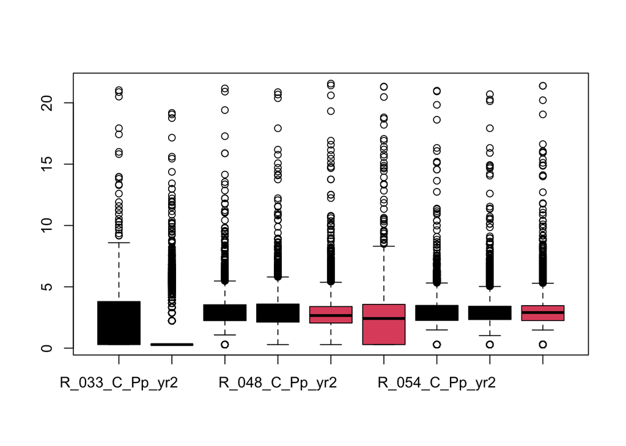

```r
boxplot(dat, col=meta$group)
```

### Transpose rlogged counts

```r
dat_t <- data.table::transpose(dat)

# get row and colnames in order
colnames(dat_t) <- rownames(dat)
rownames(dat_t) <- colnames(dat)
dat <- dat_t
dim(dat)
```

```
## [1]    9 7397
```